# **Bubble Sort**

Algoritma pengurutan yang pertama adalah *Bubble Sort*. Algoritma ini dikenal sebagai algoritma pengurutan yang membutuhkan waktu paling lama, hanya saja algoritma ini adalah algoritma pengurutan yang paling sederhana.

*Bubble sort* mengurutkan data dengan cara sebagai berikut :

1. data dibaca mulai dari paling kiri atau mulai dari indeks ke 0 (phyton) dari suatu list data
2. Bandingkan antara dua buah data yang saling berdekatan (antara data ke i dan i+1), tukar posisi jika data ke-i lebih besar dibandingkan data ke-i+1 (pengurutan secara ascending)
3. pindah satu posisi
4. lakukan perbandingan seperti langkah ke-2 dan pindah satu posisi kembali seperti langkah ke-3. Lakukan terus menerus sampai indeks data terakhir.
5. Setelah langkah ke-4 dilakukan, maka data yang berada di posisi paling kanan (indeks ke-N) adalah data terbesar .
6. Ulangi lagi langkah 1-4 dimulai dari indeks data ke 0 sampai dengan indeks ke N-1, N-2, ..., 0

Setiap iterasi berakhir, data yang terletak di posisi paling kanan adalah data yang paling besar, oleh karena itu algoritma ini disebut dengan 'bubble' karena data terbesar disetiap iterasi berakhir bergerak keatas seperti halnya gelembung. Berikut ilustrasi algoritma bubble sort pada tiap iterasi. Misalkan terdapat data [7, 2.5, 5. 10, 1].

**Iterasi Pertama**, bertujuan untuk memindahkan data terbesar, yaitu 10, ke posisi terakhir atau paling kanan dari list (karena proses pengurutan secara ascending (dari kecil-ke besar). Proses iterasi pertama ini dapat dilihat pada Gambar 1.

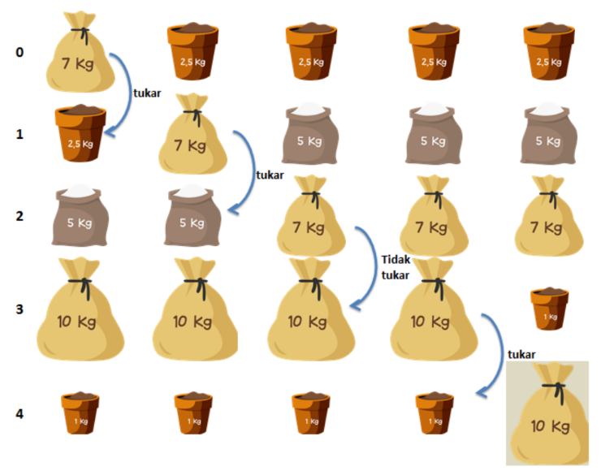

**Gambar 1. Iterasi Pertama Bubble Sort**

**Iterasi Kedua**, bertujuan untuk memindahkan data terbesar kedua, yaitu 7, agar menempati posisi tepat sebelum data 10, seperti yang terlihat pada Gambar 2.

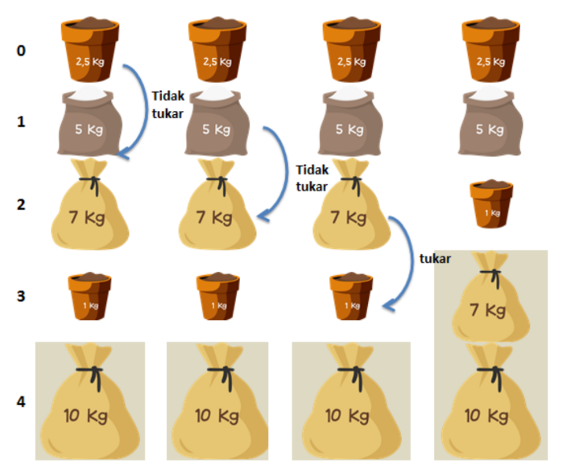

**Gambar 2. Iterasi Kedua Bubble Sort**

**Iterasi Ketiga**, bertujuan untuk memindahkan data terbesar ketiga, yaitu 5, untuk menempati posisi tepat sebelum data 7, seperti yang ditunjukkan pada Gambar 3.

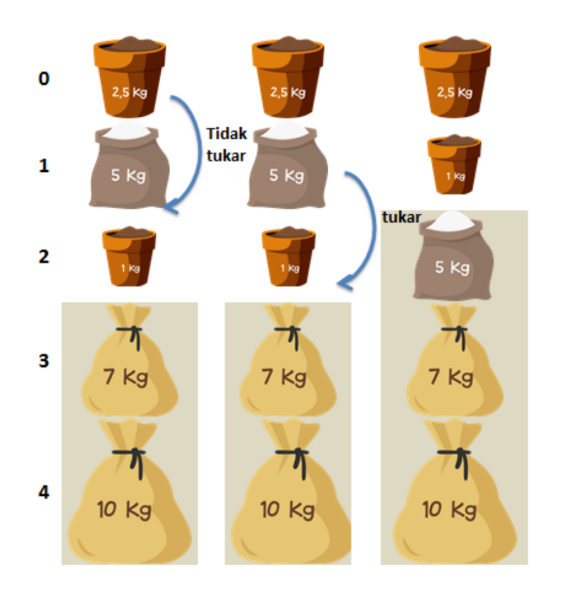

**Gambar 3. Iterasi Ketiga Bubble Sort**

Proses ini dilakukan terus menerus sampai tidak ada data lagi yang akan dibandingkan. Data dalam keadaan terurut, dapat dilihat pada Gambar 4.

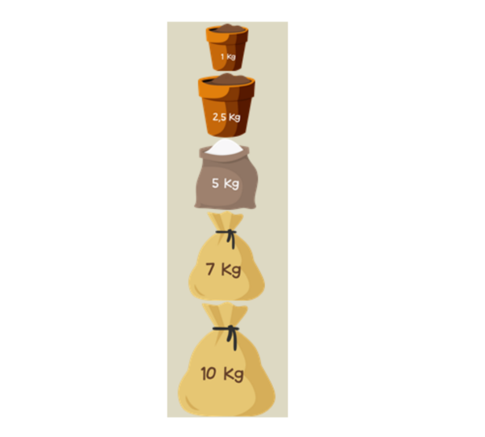

**Gambar 4. Iterasi Terakhir Bubble Sort**

## **Code**

Berikut implementsi lgoritma *bubble sort*.

```python
def bubbleSort(listData):
    print('Data yang akan diurutkan : ', listData)
    count=0
    for outIter in range(len(listData)-1,-1,-1):
        print('outIter=',outIter)
        # count=count+1
        print ('Iterasi ke-', count,':')
        for i in range(outIter):
            if listData[i]>listData[i+1]:
                # temp=listData[i]
                # listData[i]=listData[i+1]
                # listData[i+1]=temp
                listData[i],listData[i+1]=listData[i+1],listData[i]
                count+=1
            print(outIter,'=',listData)
        # print("Jumlah Swap =",count)
    print('Data urut-',listData)
    # print("Total Swap =",count)
```

```python
a=[4,3,2,1]
bubbleSort(a)
# b=[12,11,5,1,0]
# print('--')
# bubbleSort(b)
```

```
Data yang akan diurutkan :  [4, 3, 2, 1]
outIter= 3
Iterasi ke- 0 :
3 = [3, 4, 2, 1]
3 = [3, 2, 4, 1]
3 = [3, 2, 1, 4]
outIter= 2
Iterasi ke- 3 :
2 = [2, 3, 1, 4]
2 = [2, 1, 3, 4]
outIter= 1
Iterasi ke- 5 :
1 = [1, 2, 3, 4]
outIter= 0
Iterasi ke- 6 :
Data urut- [1, 2, 3, 4]
```

```python
b=[11,12,1,5]
bubbleSort(b)
```

```
Data yang akan diurutkan :  [11, 12, 1, 5]
outIter= 3
Iterasi ke- 0 :
3 = [11, 12, 1, 5]
3 = [11, 1, 12, 5]
3 = [11, 1, 5, 12]
outIter= 2
Iterasi ke- 2 :
2 = [1, 11, 5, 12]
2 = [1, 5, 11, 12]
outIter= 1
Iterasi ke- 4 :
1 = [1, 5, 11, 12]
outIter= 0
Iterasi ke- 4 :
Data urut- [1, 5, 11, 12]
```

```python
b=[10,2,5,8,1,20,2,2,4]
bubbleSort(b)
```

```
Data yang akan diurutkan :  [10, 2, 5, 8, 1, 20, 2, 2, 4]
outIter= 8
Iterasi ke- 0 :
8 = [2, 10, 5, 8, 1, 20, 2, 2, 4]
8 = [2, 5, 10, 8, 1, 20, 2, 2, 4]
8 = [2, 5, 8, 10, 1, 20, 2, 2, 4]
8 = [2, 5, 8, 1, 10, 20, 2, 2, 4]
8 = [2, 5, 8, 1, 10, 20, 2, 2, 4]
8 = [2, 5, 8, 1, 10, 2, 20, 2, 4]
8 = [2, 5, 8, 1, 10, 2, 2, 20, 4]
8 = [2, 5, 8, 1, 10, 2, 2, 4, 20]
outIter= 7
Iterasi ke- 7 :
7 = [2, 5, 8, 1, 10, 2, 2, 4, 20]
7 = [2, 5, 8, 1, 10, 2, 2, 4, 20]
7 = [2, 5, 1, 8, 10, 2, 2, 4, 20]
7 = [2, 5, 1, 8, 10, 2, 2, 4, 20]
7 = [2, 5, 1, 8, 2, 10, 2, 4, 20]
7 = [2, 5, 1, 8, 2, 2, 10, 4, 20]
7 = [2, 5, 1, 8, 2, 2, 4, 10, 20]
outIter= 6
Iterasi ke- 11 :
6 = [2, 5, 1, 8, 2, 2, 4, 10, 20]
6 = [2, 1, 5, 8, 2, 2, 4, 10, 20]
6 = [2, 1, 5, 8, 2, 2, 4, 10, 20]
6 = [2, 1, 5, 2, 8, 2, 4, 10, 20]
6 = [2, 1, 5, 2, 2, 8, 4, 10, 20]
6 = [2, 1, 5, 2, 2, 4, 8, 10, 20]
outIter= 5
Iterasi ke- 15 :
5 = [1, 2, 5, 2, 2, 4, 8, 10, 20]
5 = [1, 2, 5, 2, 2, 4, 8, 10, 20]
5 = [1, 2, 2, 5, 2, 4, 8, 10, 20]
5 = [1, 2, 2, 2, 5, 4, 8, 10, 20]
5 = [1, 2, 2, 2, 4, 5, 8, 10, 20]
outIter= 4
Iterasi ke- 19 :
4 = [1, 2, 2, 2, 4, 5, 8, 10, 20]
4 = [1, 2, 2, 2, 4, 5, 8, 10, 20]
4 = [1, 2, 2, 2, 4, 5, 8, 10, 20]
4 = [1, 2, 2, 2, 4, 5, 8, 10, 20]
outIter= 3
Iterasi ke- 19 :
3 = [1, 2, 2, 2, 4, 5, 8, 10, 20]
3 = [1, 2, 2, 2, 4, 5, 8, 10, 20]
3 = [1, 2, 2, 2, 4, 5, 8, 10, 20]
outIter= 2
Iterasi ke- 19 :
2 = [1, 2, 2, 2, 4, 5, 8, 10, 20]
2 = [1, 2, 2, 2, 4, 5, 8, 10, 20]
outIter= 1
Iterasi ke- 19 :
1 = [1, 2, 2, 2, 4, 5, 8, 10, 20]
outIter= 0
Iterasi ke- 19 :
Data urut- [1, 2, 2, 2, 4, 5, 8, 10, 20]
```

# **Latihan - 1**

1. Pada contoh pengurutan diatas (data b), urutan data hasil dari empat iterasi tidak mengalami perubahan apapun (karena data sudah dalam keaadaan terurut pada setelah iterasi ke-4. Modifikasi algoritma bubble sort tersebut agar iterasi terhenti ketika tidak ada lagi data yang akan ditukar posisinya (semua data sudah berada di tempat yang tepat).

```python
def optimizedBubbleSort(listData):
    print('Data yang akan diurutkan :', listData)
    count = 0

    # Perulangan mundur dari index terakhir hingga 0
    for outIter in range(len(listData)-1, -1, -1):
        count += 1
        print('Iterasi ke-', count, ':')

        tukar = False  # Flag penanda pertukaran di set False pada awal tiap iterasi

        # Perulangan untuk membandingkan data yang berdekatan
        for i in range(outIter):
            if listData[i] > listData[i+1]:
                # Tukar posisi jika data sebelah kiri lebih besar
                listData[i], listData[i+1] = listData[i+1], listData[i]
                tukar = True  # Ubah flag menjadi True karena ada pertukaran

        print(f"outIter {outIter} = {listData}")

        # Pengecekan Optimasi: Jika tidak ada pertukaran sama sekali, hentikan iterasi
        if not tukar:
            print("--> Tidak ada pertukaran lagi, iterasi dihentikan.")
            break

    print('Data urut -', listData)

# --- Contoh Penggunaan ---
# Menggunakan data dari contoh dokumen yang sudah hampir terurut
b = [11, 12, 1, 5, 0]
optimizedBubbleSort(b)
```

```
Data yang akan diurutkan : [11, 12, 1, 5, 0]
Iterasi ke- 1 :
outIter 4 = [11, 1, 5, 0, 12]
Iterasi ke- 2 :
outIter 3 = [1, 5, 0, 11, 12]
Iterasi ke- 3 :
outIter 2 = [1, 0, 5, 11, 12]
Iterasi ke- 4 :
outIter 1 = [0, 1, 5, 11, 12]
Iterasi ke- 5 :
outIter 0 = [0, 1, 5, 11, 12]
--> Tidak ada pertukaran lagi, iterasi dihentikan.
Data urut - [0, 1, 5, 11, 12]
```

2. Buat modifikasi algoritma bubble sort. Jika pada algoritma bubble sort, pointer bergerak dari kiri ke kanan (menuju index terakhir), sedemikian hingga data terbesar berada pada index terakhir. Modifikasi yang dilakukan adalah, setelah data terbesar terletak pada index terakhir. Pointer bergerak lagi dengan arah sebaliknya, yaitu dari kanan ke kiri untuk membawa data terkecil ke index paling awal (bidirectional bubble sort)

```python
def bidirectionalBubbleSort(listData):
    print('Data yang akan diurutkan :', listData)

    kiri = 0
    kanan = len(listData) - 1
    count = 0

    while kiri < kanan:
        count += 1
        print(f'\nIterasi Bolak-Balik ke-{count}:')
        tukar = False

        # 1. Bergerak dari KIRI ke KANAN (Membawa nilai TERBESAR ke kanan)
        for i in range(kiri, kanan):
            if listData[i] > listData[i+1]:
                # Tukar posisi
                listData[i], listData[i+1] = listData[i+1], listData[i]
                tukar = True

        kanan -= 1  # Kurangi batas kanan karena elemen paling kanan sudah pasti yang terbesar
        print(f'  Arah Kiri->Kanan: {listData}')

        # Jika tidak ada pertukaran saat bergerak ke kanan, data sudah urut
        if not tukar:
            break

        tukar = False # Reset flag untuk pergerakan arah sebaliknya

        # 2. Bergerak dari KANAN ke KIRI (Membawa nilai TERKECIL ke kiri)
        # Menggunakan langkah -1 untuk perulangan mundur
        for i in range(kanan, kiri, -1):
            # Bandingkan dengan elemen sebelumnya (i-1)
            if listData[i] < listData[i-1]:
                # Tukar posisi
                listData[i], listData[i-1] = listData[i-1], listData[i]
                tukar = True

        kiri += 1  # Tambahkan batas kiri karena elemen paling kiri sudah pasti yang terkecil
        print(f'  Arah Kanan->Kiri: {listData}')

        # Jika tidak ada pertukaran saat bergerak ke kiri, data sudah urut
        if not tukar:
            break

    print('\nData urut -', listData)

# --- Contoh Penggunaan ---
# Menggunakan contoh array acak
c = [10, 2, 5, 8, 1, 20, 2, 2, 4]
bidirectionalBubbleSort(c)
```

```
Data yang akan diurutkan : [10, 2, 5, 8, 1, 20, 2, 2, 4]

Iterasi Bolak-Balik ke-1:
  Arah Kiri->Kanan: [2, 5, 8, 1, 10, 2, 2, 4, 20]
  Arah Kanan->Kiri: [1, 2, 5, 8, 2, 10, 2, 4, 20]

Iterasi Bolak-Balik ke-2:
  Arah Kiri->Kanan: [1, 2, 5, 2, 8, 2, 4, 10, 20]
  Arah Kanan->Kiri: [1, 2, 2, 5, 2, 8, 4, 10, 20]

Iterasi Bolak-Balik ke-3:
  Arah Kiri->Kanan: [1, 2, 2, 2, 5, 4, 8, 10, 20]
  Arah Kanan->Kiri: [1, 2, 2, 2, 4, 5, 8, 10, 20]

Iterasi Bolak-Balik ke-4:
  Arah Kiri->Kanan: [1, 2, 2, 2, 4, 5, 8, 10, 20]

Data urut - [1, 2, 2, 2, 4, 5, 8, 10, 20]
```

# **Chalenge**

```python
def bubbleSort1(listData):
    print('Data yang akan diurutkan : ', listData)
    count=0
    for outIter in range(len(listData)-1,-1,-1):
        print('outIter=',outIter)
        # count=count+1
        tukar = False
        print ('Iterasi ke-', count,':')
        for i in range(outIter):
            if listData[i]>listData[i+1]:
                # temp=listData[i]
                # listData[i]=listData[i+1]
                # listData[i+1]=temp
                listData[i],listData[i+1]=listData[i+1],listData[i]
                count+=1
                tukar = True

            print(outIter,'=',listData)
        if not tukar:
            print("Looping berhenti")
            break
        # print("Jumlah Swap =",count)
    print('Data urut-',listData)
    # print("Total Swap =",count)
```

```python
a=[12,0,5]
bubbleSort1(a)
```

```
Data yang akan diurutkan :  [12, 0, 5]
outIter= 2
Iterasi ke- 0 :
2 = [0, 12, 5]
2 = [0, 5, 12]
outIter= 1
Iterasi ke- 2 :
1 = [0, 5, 12]
Looping berhenti
Data urut- [0, 5, 12]
```

# **Latihan Mandiri**

**1.** Urutkan data dengan bubble sort dan tampilkan langkah.

```python
def bubble_sort(arr):
    n = len(arr)
    print(f"Data awal: {arr}\n")

    # Loop untuk setiap iterasi
    for i in range(n):
        swapped = False
        print(f"--- Iterasi ke-{i+1} ---")

        # Loop untuk membandingkan elemen berdekatan
        # n-i-1 karena elemen terakhir di setiap iterasi sudah pasti terurut
        for j in range(0, n-i-1):
            print(f"Bandingkan {arr[j]} dan {arr[j+1]}: ", end="")

            if arr[j] > arr[j+1]:
                # Tukar posisi
                arr[j], arr[j+1] = arr[j+1], arr[j]
                swapped = True
                print(f"Tukar posisinya -> {arr}")
            else:
                print("Posisinya tetap")

        # Optimalisasi: Jika tidak ada yang ditukar, berarti sudah terurut
        if not swapped:
            print("Tidak ada elemen yang ditukar, proses dihentikan lebih awal.\n")
            break

        print(f"Hasil sementara setelah iterasi ke-{i+1}: {arr}\n")

# Contoh penggunaan
data_acak = [5, 1, 4, 2, 8]
bubble_sort(data_acak)

print(f"Data akhir yang sudah terurut: {data_acak}")
```

```
Data awal: [5, 1, 4, 2, 8]

--- Iterasi ke-1 ---
Bandingkan 5 dan 1: Tukar posisinya -> [1, 5, 4, 2, 8]
Bandingkan 5 dan 4: Tukar posisinya -> [1, 4, 5, 2, 8]
Bandingkan 5 dan 2: Tukar posisinya -> [1, 4, 2, 5, 8]
Bandingkan 5 dan 8: Posisinya tetap
Hasil sementara setelah iterasi ke-1: [1, 4, 2, 5, 8]

--- Iterasi ke-2 ---
Bandingkan 1 dan 4: Posisinya tetap
Bandingkan 4 dan 2: Tukar posisinya -> [1, 2, 4, 5, 8]
Bandingkan 4 dan 5: Posisinya tetap
Hasil sementara setelah iterasi ke-2: [1, 2, 4, 5, 8]

--- Iterasi ke-3 ---
Bandingkan 1 dan 2: Posisinya tetap
Bandingkan 2 dan 4: Posisinya tetap
Tidak ada elemen yang ditukar, proses dihentikan lebih awal.

Data akhir yang sudah terurut: [1, 2, 4, 5, 8]
```

**2.** Buat program bubble sort ascending.

```python
def bubble_sort_ascending(arr):
    n = len(arr)

    # Loop untuk melewati semua elemen array
    for i in range(n):
        swapped = False

        # Loop kedua untuk membandingkan elemen yang berdekatan
        for j in range(0, n - i - 1):

            # Jika elemen kiri lebih besar dari elemen kanan, maka tukar
            if arr[j] > arr[j + 1]:
                arr[j], arr[j + 1] = arr[j + 1], arr[j]
                swapped = True

        # Berhenti jika tidak ada elemen yang ditukar (sudah terurut)
        if not swapped:
            break

    return arr

# --- Menjalankan Program Secara Langsung ---

# Contoh data acak
data = [64, 34, 25, 12, 22, 11, 90]

print(f"Data sebelum diurutkan: {data}")

# Memanggil fungsi bubble sort
data_terurut = bubble_sort_ascending(data)

print(f"Data setelah diurutkan (Ascending): {data_terurut}")
```

```
Data sebelum diurutkan: [64, 34, 25, 12, 22, 11, 90]
Data setelah diurutkan (Ascending): [11, 12, 22, 25, 34, 64, 90]
```

**3.** Bubble sort descending.

```python
def bubble_sort_descending(arr):
    n = len(arr)

    # Loop untuk melewati semua elemen array
    for i in range(n):
        swapped = False

        # Loop kedua untuk membandingkan elemen yang berdekatan
        for j in range(0, n - i - 1):

            # Kunci Descending: Jika elemen kiri LEBIH KECIL dari elemen kanan, tukar posisinya
            if arr[j] < arr[j + 1]:
                arr[j], arr[j + 1] = arr[j + 1], arr[j]
                swapped = True

        # Berhenti jika tidak ada elemen yang ditukar (sudah terurut)
        if not swapped:
            break

    return arr

# --- Menjalankan Program Secara Langsung ---

# Contoh data acak
data = [64, 34, 25, 12, 22, 11, 90]

print(f"Data sebelum diurutkan: {data}")

# Memanggil fungsi bubble sort descending
data_terurut = bubble_sort_descending(data)

print(f"Data setelah diurutkan (Descending): {data_terurut}")
```

```
Data sebelum diurutkan: [64, 34, 25, 12, 22, 11, 90]
Data setelah diurutkan (Descending): [90, 64, 34, 25, 22, 12, 11]
```

**4.** Hitung jumlah swap.

```python
def bubble_sort_descending(arr):
    n = len(arr)
    swap_count = 0  # Inisialisasi variabel untuk menghitung swap

    # Loop untuk melewati semua elemen array
    for i in range(n):
        swapped = False

        # Loop kedua untuk membandingkan elemen yang berdekatan
        for j in range(0, n - i - 1):

            # Jika elemen kiri lebih kecil dari elemen kanan, tukar
            if arr[j] < arr[j + 1]:
                arr[j], arr[j + 1] = arr[j + 1], arr[j]
                swapped = True
                swap_count += 1  # Tambahkan 1 ke penghitung setiap kali terjadi pertukaran

        # Berhenti jika tidak ada elemen yang ditukar (sudah terurut)
        if not swapped:
            break

    # Kembalikan dua nilai: array yang sudah terurut dan jumlah swap-nya
    return arr, swap_count

# --- Menjalankan Program Secara Langsung ---

# Contoh data acak
data = [64, 34, 25, 12, 22, 11, 90]

print(f"Data sebelum diurutkan: {data}")

# Memanggil fungsi dan menangkap dua nilai yang dikembalikan
data_terurut, total_swap = bubble_sort_descending(data)

print(f"Data setelah diurutkan (Descending): {data_terurut}")
print(f"Jumlah total swap yang terjadi: {total_swap}")
```

```
Data sebelum diurutkan: [64, 34, 25, 12, 22, 11, 90]
Data setelah diurutkan (Descending): [90, 64, 34, 25, 22, 12, 11]
Jumlah total swap yang terjadi: 7
```